# Metrics to Assess How Well Dimension Reduction Methods Preserve Data Set Properties

Kevin R. Coombes and Polina Bombina

# Introduction

The introduction of high dimensional technologies in molecular biology, which perform genome-scale measurements on DNA, RNA, or protein, has been accompanied by more extensive use of “dimension reduction” (DR) algorithms that promote visualization of important aspects of the data in just two dimensions. However, it is critical to understand the extent to which different DR algorithms distort the properties of the data set that are present in the original high dimensional space. The `Preservation` R package collects together some metrics to aid our understanding.

# Preparation

## Packages

As a first step, we must load the `Preservation` library package.

```r
library(Preservation)
```

## Sample Data

We need some data in order to illustrate the preservation metrics. Here we use a subset of the CAVA CD4 T-cell single-cell CITE-Seq data set [1]. This data set was previously identified as a single coherent cluster in the much larger complete data set. It contains measurements of the expression of 51 proteins in 3096 individual cells. We also sub-clustered this subset into four parts to help with visualization.

```r
data("prot5")
dim(prot5)
```

```
## [1] 3096   51
```

```r
table(colvec)
```

```
## colvec
## #69DE69 #9FC7FF #C882D9 #FFA4A4
##     812     596     641    1047
```

Next, we applied four popular dimension reduction methods:

1. Multi-Dimensional Scaling (MDS), which is equivalent to principal components analysis (OCA) when using Euclidean distance.
2. t-Stochastic Neighbor Embedding (t-SNE or TSNE).
3. Uniform Manifold Approximation and Projection (UMAP).
4. Diffusion Maps (DM).

The first two DR algorithms (MDS and TSNE) were computed using the `Rdimtools` package; UMAP, using the `umap` package; and DM, using the `diffusionMap` package.

```r
data("drs")
sapply(drs, dim)
```

```
##       MDS TSNE UMAP   DM
## [1,] 3096 3096 3096 3096
## [2,]    2    2    2    2
```

Here is an initial plot showing the dimension reduction results.

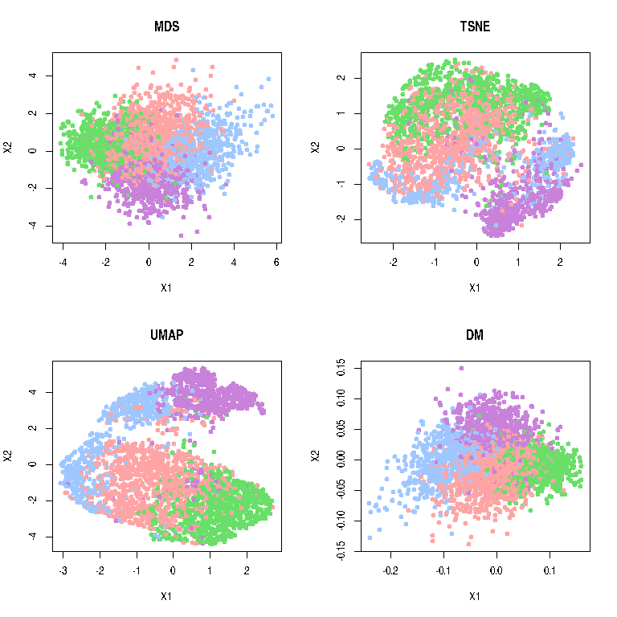

Four views of the CAVA subset after dimension reduction.

```r
opar <- par(mfrow = c(2,2))
for (tag in names(drs)) {
  plot(drs[[tag]], col = colvec, pch = 16, main = tag, xlab = "X1", ylab = "X2")
}
```

```r
par(opar)
```

We first note that MDS and DM produce essentially the same plot, after recognizing that DM has switched the (arbitrary) signs of both components. By contrast, both UMAP and TSNE have tried to place the purple group and half of the blue group in a separate cluster. The TSNE algorithm is slightly more extreme, since it also seems to have “flipped” that new cluster so that the two halves of the blue group are further apart.

# Preservation of Pairwise Distances

Some DR algorithms are designed to try to preserve the pairwise distances between points in the data set. MDS is the most explicit example of such an algorithm, since its defined goal is to preserve the average of these distances as well as possible.

The `Preservation` package includes six metrics to assess how well pairwise distances are preserved. Here we apply five of these metrics to the four different DR views of the CAVA dataset. (We omit Spearman’s Rho, since it is somewhat slower than the others.)

```r
hiD <- dist(prot5)
loD <- lapply(drs, dist)
suppressWarnings(
  scores <- sapply(c("MilnorDistortion", "SigmaDistortion", "Stress",
                     "EarthMover"), function(metric) {
    cat(metric, "\n", file = stderr())
    FUN <- get(metric)
    sapply(names(drs), function(tag) {
      FUN(hiD, loD[[tag]])
    })
  })
)
m1d <- sapply(names(drs), function(tag) {
  M1Distortion(prot5, drs[[tag]])
})
scores <- cbind(scores, M1Distortion = m1d)
round(scores, 3)
```

```
##      MilnorDistortion SigmaDistortion Stress EarthMover M1Distortion
## MDS             8.353           0.378  0.569      0.012        0.750
## TSNE            8.609           0.455  0.666      0.025        0.853
## UMAP            9.234           0.696  0.497      0.051        0.530
## DM              8.139           0.963  0.983      1.016        1.000
```

```r
Preservation:::PWBest(colnames(scores))
```

```
## MilnorDistortion  SigmaDistortion           Stress       EarthMover
##                0                0                0                0
##     M1Distortion
##                0
```

# Neighborhood Preservation

Method like TSNE and UMAP are inherently non-linear, and their heuristic is to try to preserve local neighborhoods of points rather than all pairwise distances. The `Preservation` package includes several metrics to assess how well neighborhoods are preserved. These metrics are naturally functions of the number, $k$, of nearest neighbors defining a neighborhood.

```r
ajd <-sapply(names(drs), function(tag) {
  AverageJaccardDistance(prot5, drs[[tag]], k = 50)
})
scores <- cbind(scores, ajd)
# too slow: qnx <- QNX(hiD, loD[["MDS"]])
quad <- c(MDS = "#B00068", TSNE = "#1C8356", UMAP = "#325A9B", DM = "#FEAF16" )
ct <- lapply(names(drs), function(tag) {
  Preservation:::compute_ct_list(prot5, drs[[tag]])
})
avtrust <- sapply(ct, function(X) X[,3])
colnames(avtrust) <- names(drs)

avcont <- sapply(ct, function(X) X[,6])
colnames(avcont) <- names(drs)
```

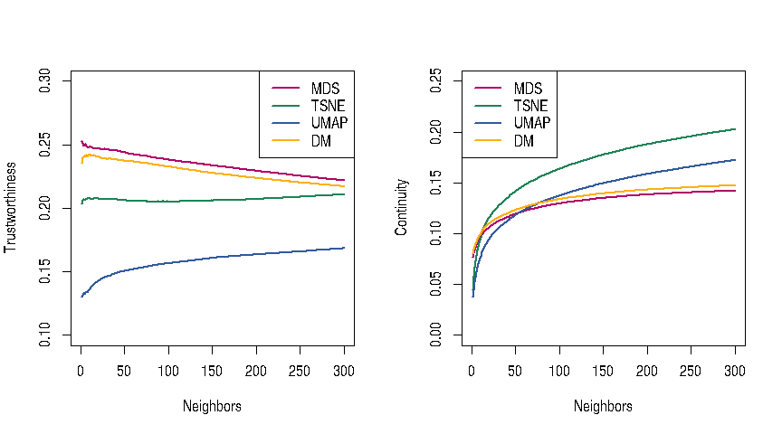

```r
opar <- par(mfrow = c(1,2))
plot(avtrust[,1], type = "n", ylim = c(0.1, 0.3), xlab = "Neighbors", ylab = "Trustworthiness")
for (tag in names(drs)) lines(avtrust[, tag], lwd = 2, col = quad[tag])
legend("topright", names(drs), col = quad, lwd = 2)

plot(avcont[,1], type = "n", ylim = c(0, 0.25), xlab = "Neighbors", ylab = "Continuity")
for (tag in names(drs)) lines(avcont[, tag], lwd = 2, col = quad[tag])
legend("topleft", names(drs), col = quad, lwd = 2)
```

```r
par(opar)
```

# Path Preservation

```r
data("path-idex")
length(idex)
```

```
## [1] 310
```

```r
highD <- prot5[idex,]
dim(highD)
```

```
## [1] 310  51
```

Here is a plot showing the dimension reductions with the overlaid image of the PC1 path.

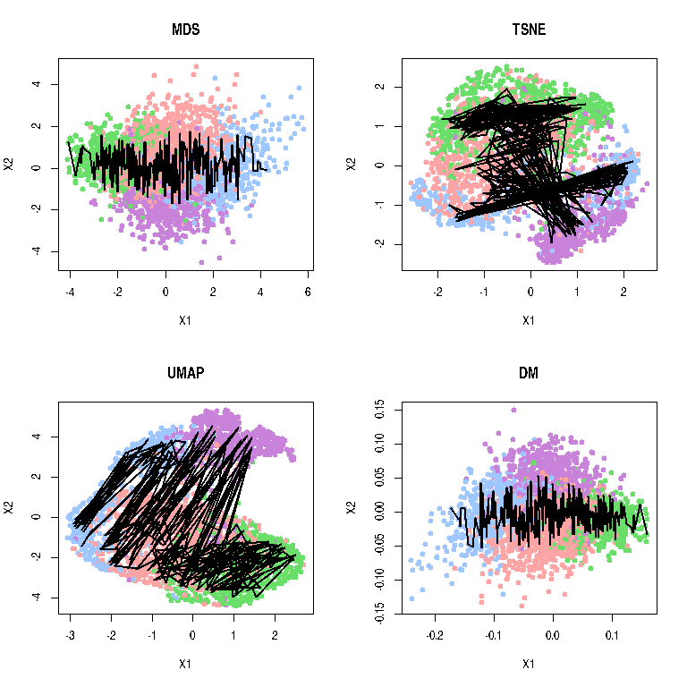

Four views of the path of the first principal components of the CAVA subset after dimension reduction.

```r
opar <- par(mfrow = c(2,2))
for (tag in names(drs)) {
  lowD <- drs[[tag]][idex,]
  plot(drs[[tag]], col = colvec, pch = 16, main = tag, xlab = "X1", ylab = "X2")
  lines(lowD, lwd = 2)
}
```

```r
par(opar)
```

Again, the paths in the MDS and DM reductions jitter about the first component axis. In the UMAP and TSNE reductions, the path seems to do a lot of jumping between the two pseudo-clusters in the plot. In the TSNE plot, there are also numerous jumps between the two halves of the blue group.

```r
scores <- sapply(c("LengthDistortion", "SegmentVariance", "Curvature", "SpatialSimilarity"),
                 function(metric) {
  FUN <- get(metric)
  sapply(names(drs), function(tag) {
    lowD <- drs[[tag]][idex,]
    FUN(highD, lowD)
  })
})
round(scores, 3)
```

```
##      LengthDistortion SegmentVariance Curvature SpatialSimilarity
## MDS             1.587          -0.520    -0.004            -0.649
## TSNE            1.184          -1.501     0.001            -0.810
## UMAP            0.671          -2.632     0.010            -0.493
## DM              5.128           6.557    -0.021            -1.619
```

```r
Preservation:::PathBest(colnames(scores))
```

```
##  LengthDistortion   SegmentVariance         Curvature SpatialSimilarity
##                 0                 0                 0                 0
```

Each of the four metrics we have looked at compares the measurements on original and reduced data sets by computing their log ratio (which is why the best score is the one nearest zero). Here are variants that use Spearman’s rank correlation instead, where te best score would be the score closest to one. here length and curvature are topped by the UMAP and TSNE methods, while spatial imilarity is better with the DM and MDS algorithms.

```r
rscores <- sapply(c("RankLengthDistortion", "RankCurvature", "RankSpatialSimilarity"),
                 function(metric) {
  FUN <- get(metric)
  sapply(names(drs), function(tag) {
    lowD <- drs[[tag]][idex,]
    FUN(highD, lowD)
  })
})
round(rscores, 3)
```

```
##      RankLengthDistortion RankCurvature RankSpatialSimilarity
## MDS                 0.265         0.247                 0.835
## TSNE                0.480         0.371                 0.629
## UMAP                0.477         0.330                 0.654
## DM                  0.316         0.258                 0.836
```

```r
scores <- cbind(scores, rscores)
```

We find it surprising that UMAP and TSNE rank so highly under many of these metrics. Perhaps we need to look more broadly to find metrics that give results that match our expectations?

One idea is to look at a smooth version of the path in the reduced spaces. Here is a plot showing the dimension reductions with the overlaid image of smoothed PC1 path.

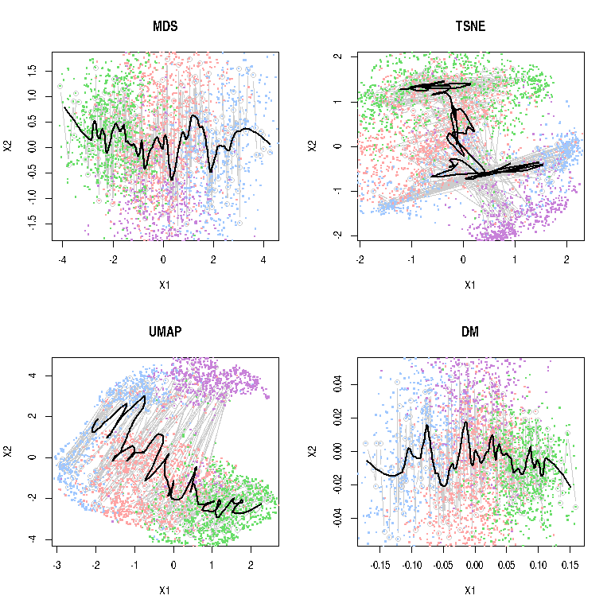

Four views of the smoothed PC1 path of the CAVA subset after dimension reduction.

```r
smoosh <- function( coords) {
  ticks <- 1:nrow(coords) # arbitrary parametrization
  ## fit smooth curve to each coordinate as a function of the parameter
  fitted <- apply(coords, 2, function(X) predict(loess(X ~ ticks, span = 0.1)))
  delta <- fitted - coords # difference between actual path and smooth fitted curve
  val <- list(coords = coords, fitted = fitted, delta = delta)
  class(val) <- "smoosh"
  val
}
fits <- lapply(names(drs), function(tag) smoosh(drs[[tag]][idex,]))
names(fits) <- names(drs)
plot.smoosh <- function(obj, main = "", col = "purple", ...) {
  plot(obj$coords, main = main, type = "b", col = "grey80", ...)
  lines(obj$fitted, col = col, lwd = 2)
  invisible(main)
}
lines.smoosh <- function(obj, col = "purple") {
  lines(obj$fitted, col = col, lwd = 2)
}
opar <- par(mfrow = c(2, 2))
for (tag in names(fits)) {
  plot(fits[[tag]], main=tag, col = "black", xlab = "X1", ylab = "X2")
  points(drs[[tag]], col = colvec, pch = ".", cex=3)
  lines(fits[[tag]], col = "black")
}
```

```r
par(opar)
```

```r
mscores <- sapply(c("Smoothness", "Coil", "Contact", "EndpointDisplacement"),
                 function(metric) {
  cat(metric, "\n", file = stderr())
  FUN <- get(metric)
  sapply(names(drs), function(tag) {
    lowD <- drs[[tag]][idex,]
    FUN(highD, lowD)
  })
})
round(mscores, 3)
```

```
##      Smoothness   Coil Contact EndpointDisplacement
## MDS       1.595 -0.314   0.729                0.017
## TSNE      1.077  0.352   0.060                1.157
## UMAP      0.620 -0.470   0.174                0.318
## DM        5.142  2.908   0.855                3.250
```

```r
scores <- cbind(scores, mscores)
```

```r
round(t(scores), 3)
```

```
##                          MDS   TSNE   UMAP     DM
## LengthDistortion       1.587  1.184  0.671  5.128
## SegmentVariance       -0.520 -1.501 -2.632  6.557
## Curvature             -0.004  0.001  0.010 -0.021
## SpatialSimilarity     -0.649 -0.810 -0.493 -1.619
## RankLengthDistortion   0.265  0.480  0.477  0.316
## RankCurvature          0.247  0.371  0.330  0.258
## RankSpatialSimilarity  0.835  0.629  0.654  0.836
## Smoothness             1.595  1.077  0.620  5.142
## Coil                  -0.314  0.352 -0.470  2.908
## Contact                0.729  0.060  0.174  0.855
## EndpointDisplacement   0.017  1.157  0.318  3.250
```

# Appendix